# olympics

**Importing Required Libraries for Data Analysis**

```python
import pandas as pd
import numpy as np
import matplotlib.pyplot as plt
import seaborn as sns
import warnings
warnings.filterwarnings('ignore')
```

**Data Preparation**

**.** **Loading Dataset**

```python
df = pd.read_csv("C:\\Users\\aryan\\Downloads\\Summer-Olympic-medals-1976-to-2008.csv",encoding='latin1')
```

```python
df.head()
```

|  | City | Year | Sport | Discipline | Event | Athlete | Gender | Country_Code | Country | Event_gender | Medal |
| --- | --- | --- | --- | --- | --- | --- | --- | --- | --- | --- | --- |
| 0 | Montreal | 1976.0 | Aquatics | Diving | 3m springboard | KÖHLER, Christa | Women | GDR | East Germany | W | Silver |
| 1 | Montreal | 1976.0 | Aquatics | Diving | 3m springboard | KOSENKOV, Aleksandr | Men | URS | Soviet Union | M | Bronze |
| 2 | Montreal | 1976.0 | Aquatics | Diving | 3m springboard | BOGGS, Philip George | Men | USA | United States | M | Gold |
| 3 | Montreal | 1976.0 | Aquatics | Diving | 3m springboard | CAGNOTTO, Giorgio Franco | Men | ITA | Italy | M | Silver |
| 4 | Montreal | 1976.0 | Aquatics | Diving | 10m platform | WILSON, Deborah Keplar | Women | USA | United States | W | Bronze |

**head() method give top 5 value from dataset**

```python
df.shape
```

```
(15433, 11)
```

**We have 15433 rows and 11 columns in dataset**

```python
df.dtypes
```

```
City             object
Year            float64
Sport            object
Discipline       object
Event            object
Athlete          object
Gender           object
Country_Code     object
Country          object
Event_gender     object
Medal            object
dtype: object
```

**'dtypes' method give us types od data of a every particular column present in data**

**From here we can analyse 'Year' column have float data type so we will convert it into integer data type for ease**

**Data Cleaning**

```python
df.isna().sum()
```

```
City            117
Year            117
Sport           117
Discipline      117
Event           117
Athlete         117
Gender          117
Country_Code    117
Country         117
Event_gender    117
Medal           117
dtype: int64
```

**Now let's check how many null values are present in our data,"isna()" method gives us null values present in dataset**

**We can see we have 117 null values in every column as it is less than 25% of data we can drop the null values inorder to analysis of accurate data**

```python
df.dropna(inplace=True)
```

**We have succussfully dropped null values from our data,so lets check it**

```python
df.isna().sum()
```

```
City            0
Year            0
Sport           0
Discipline      0
Event           0
Athlete         0
Gender          0
Country_Code    0
Country         0
Event_gender    0
Medal           0
dtype: int64
```

**As we can see we don't have any null values left in our dataset so we can proceed with further steps**

```python
print(df.Gender.unique())
print(df.Event_gender.unique())
```

```
['Women' 'Men']
['W' 'M' 'X']
```

we have an'X'category for event gender.But since it is notan impacting factor neither there is not much to analyse,we can safe dropoff 'Event_gender'column.

Also the Country code is of no much uses in ce we have Country column.

```python
data=df.drop('Event_gender',axis =1)
data=df.drop('Country_Code',axis =1)
df.head()
```

|  | City | Year | Sport | Discipline | Event | Athlete | Gender | Country_Code | Country | Event_gender | Medal |
| --- | --- | --- | --- | --- | --- | --- | --- | --- | --- | --- | --- |
| 0 | Montreal | 1976.0 | Aquatics | Diving | 3m springboard | KÖHLER, Christa | Women | GDR | East Germany | W | Silver |
| 1 | Montreal | 1976.0 | Aquatics | Diving | 3m springboard | KOSENKOV, Aleksandr | Men | URS | Soviet Union | M | Bronze |
| 2 | Montreal | 1976.0 | Aquatics | Diving | 3m springboard | BOGGS, Philip George | Men | USA | United States | M | Gold |
| 3 | Montreal | 1976.0 | Aquatics | Diving | 3m springboard | CAGNOTTO, Giorgio Franco | Men | ITA | Italy | M | Silver |
| 4 | Montreal | 1976.0 | Aquatics | Diving | 10m platform | WILSON, Deborah Keplar | Women | USA | United States | W | Bronze |

```python
data =df[['City','Year']]
data.drop_duplicates('Year')
data
```

|  | City | Year |
| --- | --- | --- |
| 0 | Montreal | 1976.0 |
| 1 | Montreal | 1976.0 |
| 2 | Montreal | 1976.0 |
| 3 | Montreal | 1976.0 |
| 4 | Montreal | 1976.0 |
| ... | ... | ... |
| 15428 | Beijing | 2008.0 |
| 15429 | Beijing | 2008.0 |
| 15430 | Beijing | 2008.0 |
| 15431 | Beijing | 2008.0 |
| 15432 | Beijing | 2008.0 |

15316 rows × 2 columns

```python
data=df.astype({'Year':'int'})
data.head(2)
```

|  | City | Year | Sport | Discipline | Event | Athlete | Gender | Country_Code | Country | Event_gender | Medal |
| --- | --- | --- | --- | --- | --- | --- | --- | --- | --- | --- | --- |
| 0 | Montreal | 1976 | Aquatics | Diving | 3m springboard | KÖHLER, Christa | Women | GDR | East Germany | W | Silver |
| 1 | Montreal | 1976 | Aquatics | Diving | 3m springboard | KOSENKOV, Aleksandr | Men | URS | Soviet Union | M | Bronze |

**data type of 'Year' column has been converted into integer data type**

```python
df_cleaned = df.dropna()
df_cleaned.groupby('Country')['Medal'].count().sort_values(ascending=False)
```

```
Country
United States           1992
Soviet Union            1021
Australia                798
Germany                  691
China                    679
                        ...
Sri Lanka                  1
Togo                       1
United Arab Emirates       1
Uruguay                    1
Virgin Islands*            1
Name: Medal, Length: 127, dtype: int64
```

```python
data['Sport'].value_counts()
```

```
Sport
Aquatics             2210
Athletics            1523
Rowing               1377
Hockey                817
Gymnastics            783
Handball              780
Volleyball            695
Canoe / Kayak         672
Football              669
Basketball            646
Fencing               606
Wrestling             533
Cycling               483
Equestrian            423
Sailing               417
Boxing                416
Judo                  396
Shooting              345
Baseball              335
Weightlifting         311
Softball              180
Archery               162
Badminton             120
Table Tennis          120
Tennis                118
Modern Pentathlon      81
Taekwondo              80
Triathlon              18
Name: count, dtype: int64
```

```python
data['Medal'].value_counts()
```

```
Medal
Bronze    5258
Gold      5042
Silver    5016
Name: count, dtype: int64
```

```python
x=data['Year']
```

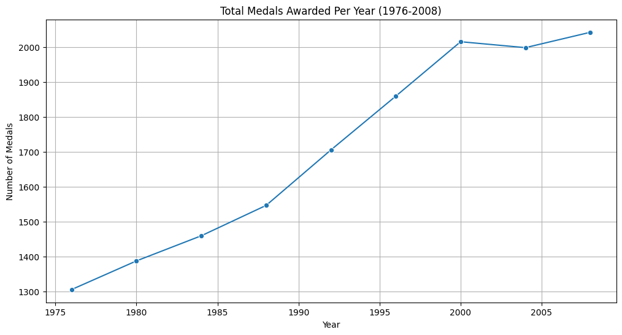

```python
medals_by_year = df.groupby('Year')['Medal'].count()
plt.figure(figsize=(12,6))
sns.lineplot(x=medals_by_year.index,y=medals_by_year.values,marker='o')
plt.title('Total Medals Awarded Per Year (1976-2008)')
plt.xlabel('Year')
plt.ylabel('Number of Medals')
plt.grid(True)
```

**The trend of total medals awarded per year shows an increasing pattern over time, with a notable jump in the number of medals awarded from 1976 to 2008.**

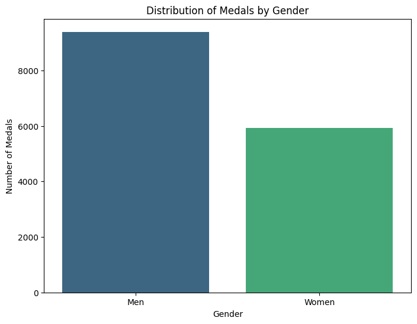

```python
gender_counts = df['Gender'].value_counts()
plt.figure(figsize=(8, 6))
sns.barplot(x=gender_counts.index, y=gender_counts.values, palette='viridis')
plt.title('Distribution of Medals by Gender')
plt.xlabel('Gender')
plt.ylabel('Number of Medals')
```

**Male athletes have won significantly more medals than female athletes, indicating a higher participation or medal-winning rate among men in the Olympics during this period.**

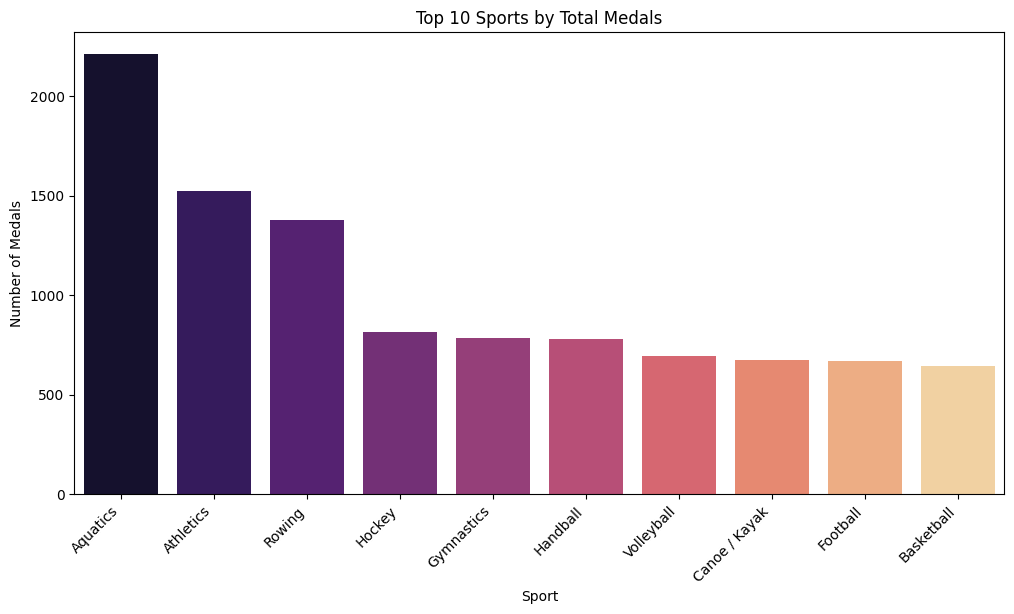

```python
sport_medals = df.groupby('Sport')['Medal'].count().sort_values(ascending=False).head(10)
plt.figure(figsize=(12, 6))
sns.barplot(x=sport_medals.index, y=sport_medals.values, palette='magma')
plt.title('Top 10 Sports by Total Medals')
plt.xlabel('Sport')
plt.ylabel('Number of Medals')
plt.xticks(rotation=45, ha='right')
plt.show()
```

**Aquatics is the sport with the highest number of medals, followed by Athletics and Rowing, reflecting their prominence in the Summer Olympics.**

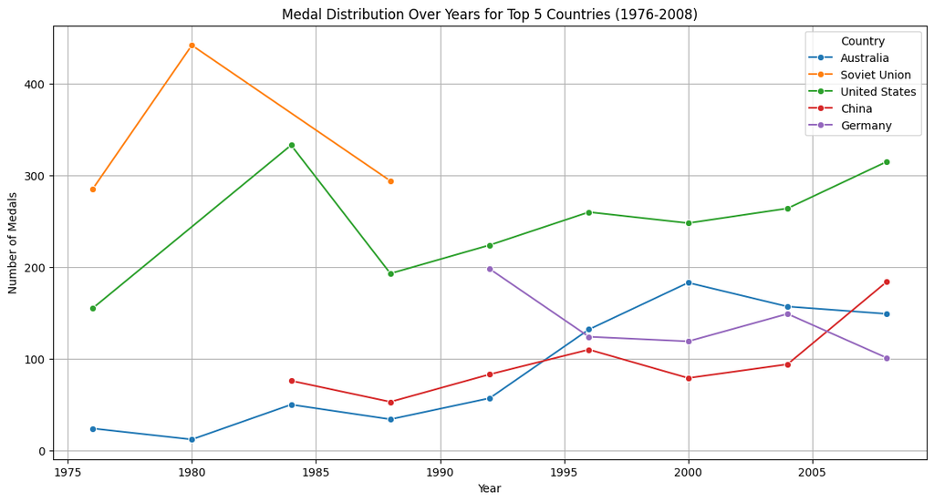

```python
top_5_countries = df.groupby('Country')['Medal'].count().nlargest(5).index
df_top_countries = df[df['Country'].isin(top_5_countries)]
medals_by_year_country = df_top_countries.groupby(['Year', 'Country'])['Medal'].count().reset_index()
plt.figure(figsize=(14, 7))
sns.lineplot(data=medals_by_year_country, x='Year', y='Medal', hue='Country', marker='o')
plt.title('Medal Distribution Over Years for Top 5 Countries (1976-2008)')
plt.xlabel('Year')
plt.ylabel('Number of Medals')
plt.grid(True)
plt.legend(title='Country')
```

**This line plot visualizes how the top 5 medal-winning countries (United States, Soviet Union, Australia, Germany, and China) have performed in terms of medal counts over the different Olympic years. It allows for a comparative analysis of their historical performance trends.**

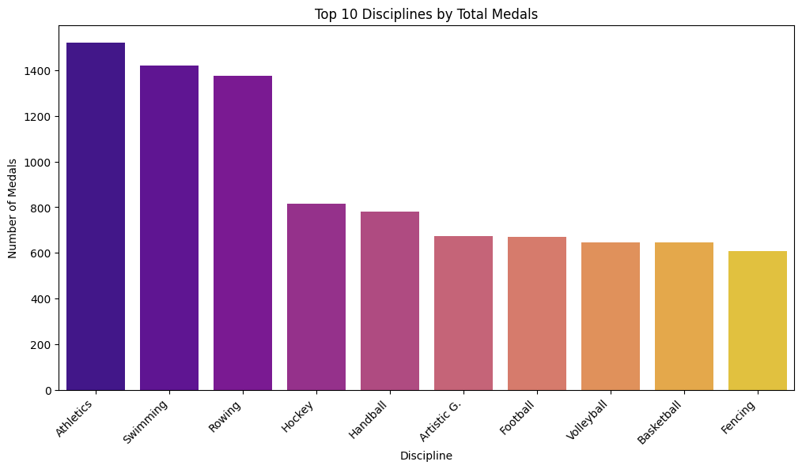

```python
discipline_medals = df.groupby('Discipline')['Medal'].count().sort_values(ascending=False).head(10)
plt.figure(figsize=(12, 6))
sns.barplot(x=discipline_medals.index, y=discipline_medals.values, palette='plasma')
plt.title('Top 10 Disciplines by Total Medals')
plt.xlabel('Discipline')
plt.ylabel('Number of Medals')
plt.xticks(rotation=45, ha='right')
plt.show()
```

**Mostly medal won in Athletics discipline followed by swimming and rowing during this olumpic duration**

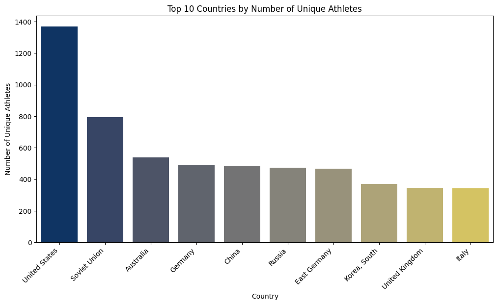

```python
athletes_by_country = df.groupby('Country')['Athlete'].nunique().sort_values(ascending=False).head(10)
plt.figure(figsize=(12, 6))
sns.barplot(x=athletes_by_country.index, y=athletes_by_country.values, palette='cividis')
plt.title('Top 10 Countries by Number of Unique Athletes')
plt.xlabel('Country')
plt.ylabel('Number of Unique Athletes')
plt.xticks(rotation=45, ha='right')
plt.show()
```

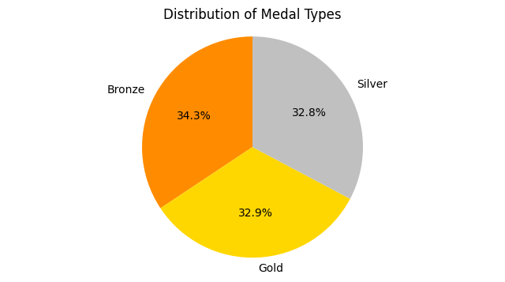

```python
medal_type_counts = df['Medal'].value_counts()
plt.figure(figsize=(8, 4))
plt.pie(medal_type_counts, labels=medal_type_counts.index, autopct='%1.1f%%', startangle=90, colors=['darkorange','gold', 'silver'])
plt.title('Distribution of Medal Types')
plt.axis('equal')
plt.show()
```

**This pie chart shows the proportion of Gold, Silver, and Bronze medals awarded in the dataset. It provides a clear visual of the overall distribution of medal types.**

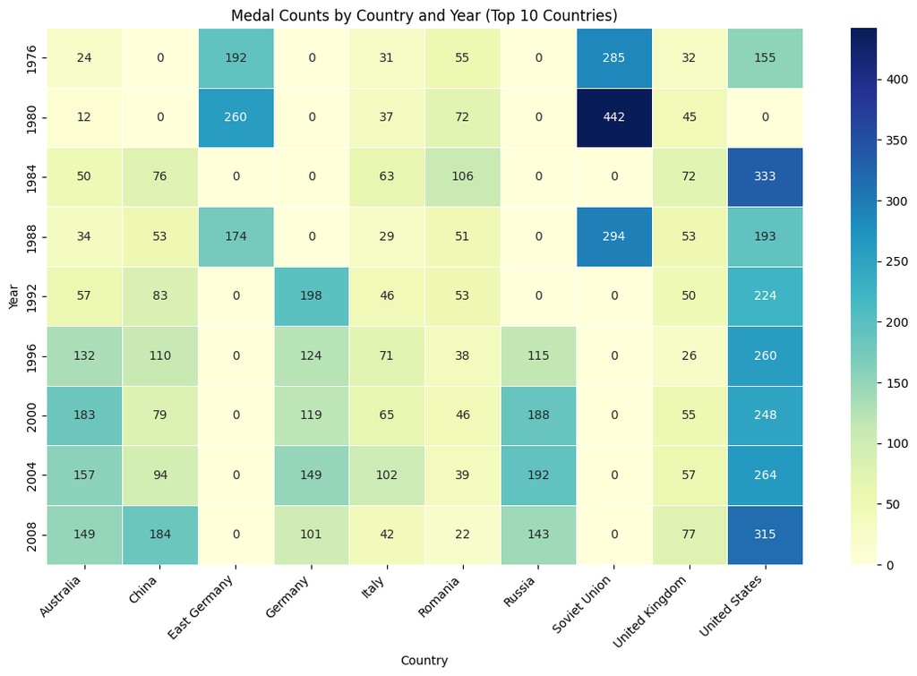

```python
top_10_countries = df.groupby('Country')['Medal'].count().nlargest(10).index
df_heatmap = df[df['Country'].isin(top_10_countries)]
medal_pivot = df_heatmap.pivot_table(index=data['Year'], columns='Country', values='Medal', aggfunc='count').fillna(0)

plt.figure(figsize=(14, 8))
sns.heatmap(medal_pivot, cmap='YlGnBu', annot=True, fmt='g', linewidths=.5)
plt.title('Medal Counts by Country and Year (Top 10 Countries)')
plt.xlabel('Country')
plt.ylabel('Year')
plt.xticks(rotation=45, ha='right')
plt.show()
```

**This heatmap visually represent distribution of medal by top 10performing countries across different Olympics Year**

*The intensity of the color indicates the number of medals, allowing for a quick overview of each country's performance over time.*

```python
top_athletes = df.groupby('Athlete')['Medal'].count().sort_values(ascending=False).head(10)
print("Top 10 Athletes with the Most Medals:\n", top_athletes.to_markdown(numalign="left", stralign="left"))
```

```
Top 10 Athletes with the Most Medals:
 | Athlete            | Medal   |
|:-------------------|:--------|
| PHELPS, Michael    | 16      |
| FISCHER, Birgit    | 12      |
| TORRES, Dara       | 12      |
| THOMPSON, Jenny    | 12      |
| ANDRIANOV, Nikolay | 12      |
| NEMOV, Alexei      | 12      |
| BIONDI, Matthew    | 11      |
| COUGHLIN, Natalie  | 11      |
| LEWIS, Carl        | 10      |
| SCHERBO, Vitaly    | 10      |
```

```python
country_medal_type = df.pivot_table(index='Country', columns='Medal', values='Athlete', aggfunc='count').fillna(0)
country_medal_type['Total'] = country_medal_type[['Gold', 'Silver', 'Bronze']].sum(axis=1)
country_medal_type = country_medal_type.sort_values(by='Total', ascending=False).head(10)
print("\nTop 10 Countries by Medal Type:\n", country_medal_type[['Gold', 'Silver', 'Bronze']].to_markdown(numalign="left", stralign="left"))
```

```
Top 10 Countries by Medal Type:
 | Country        | Gold   | Silver   | Bronze   |
|:---------------|:-------|:---------|:---------|
| United States  | 928    | 583      | 481      |
| Soviet Union   | 439    | 285      | 297      |
| Australia      | 216    | 270      | 312      |
| Germany        | 237    | 176      | 278      |
| China          | 234    | 252      | 193      |
| Russia         | 192    | 206      | 240      |
| East Germany   | 286    | 190      | 150      |
| Italy          | 145    | 163      | 178      |
| Romania        | 135    | 157      | 190      |
| United Kingdom | 122    | 157      | 188      |
```

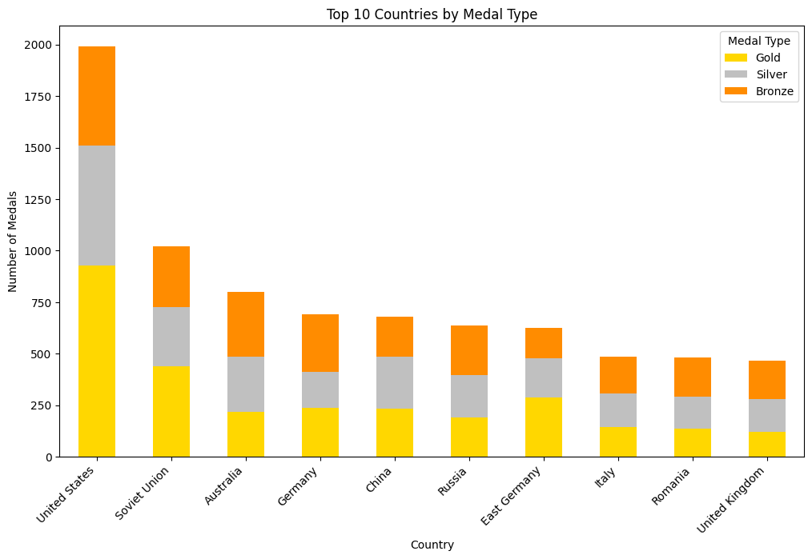

```python
country_medal_type[['Gold', 'Silver', 'Bronze']].plot(
    kind='bar',
    stacked=True,
    figsize=(12, 7),
    color=['gold', 'silver', 'darkorange']
)
plt.title('Top 10 Countries by Medal Type')
plt.xlabel('Country')
plt.ylabel('Number of Medals')
plt.xticks(rotation=45, ha='right')
plt.legend(title='Medal Type')
```

**From this graph we conclude that U.S is top performer of olympics in every aspect weaather Gold,Silver,Bronze.**

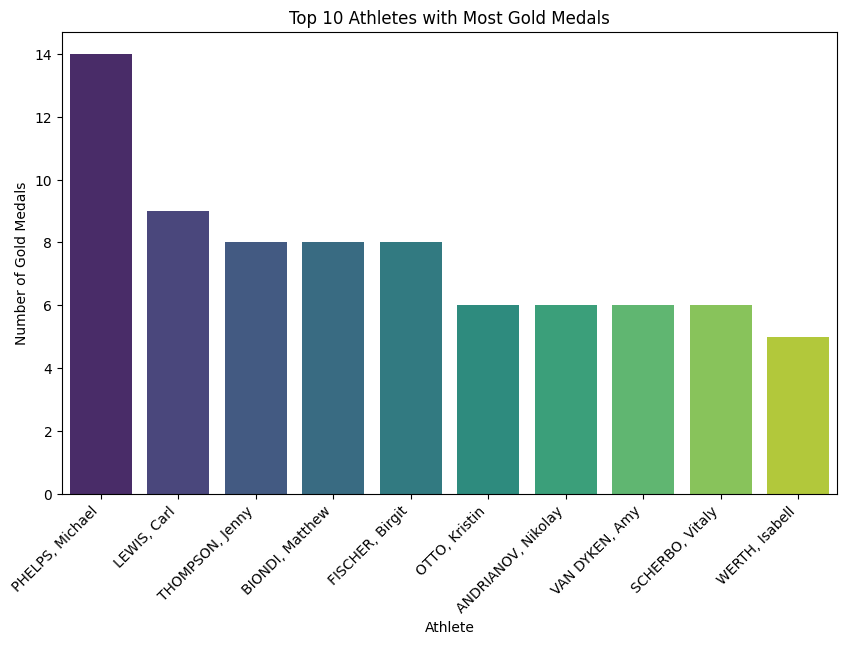

```python
gold_medals_df = df[df['Medal'] == 'Gold']
top_gold_athletes = gold_medals_df.groupby('Athlete')['Medal'].count().sort_values(ascending=False).head(10)

plt.figure(figsize=(10, 6))
sns.barplot(x=top_gold_athletes.index, y=top_gold_athletes.values, palette='viridis')
plt.title('Top 10 Athletes with Most Gold Medals')
plt.xlabel('Athlete')
plt.ylabel('Number of Gold Medals')
plt.xticks(rotation=45, ha='right')
plt.show()
```

**Top performer athletes of olympics during 1975-2008 is PHELIPS,MICHAEL follwed by LEWIS,carl**

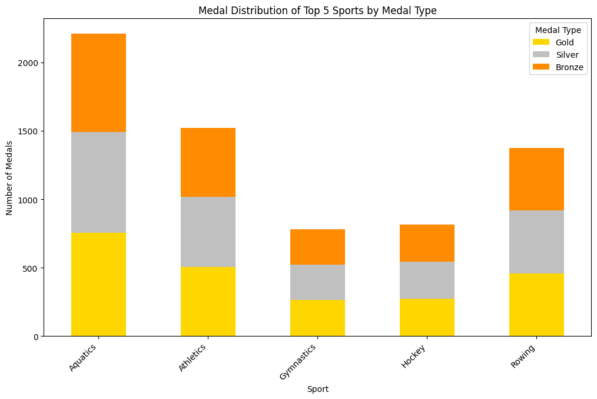

```python
top_5_sports = df['Sport'].value_counts().nlargest(5).index
df_top_sports = df[df['Sport'].isin(top_5_sports)]

medal_distribution_sport = df_top_sports.pivot_table(index='Sport', columns='Medal', values='Athlete', aggfunc='count').fillna(0)
medal_distribution_sport = medal_distribution_sport[['Gold', 'Silver', 'Bronze']] # Ensure order

medal_distribution_sport.plot(
    kind='bar',
    stacked=True,
    figsize=(12, 7),
    color=['gold', 'silver', 'darkorange']
)
plt.title('Medal Distribution of Top 5 Sports by Medal Type')
plt.xlabel('Sport')
plt.ylabel('Number of Medals')
plt.xticks(rotation=45, ha='right')
plt.legend(title='Medal Type')
```

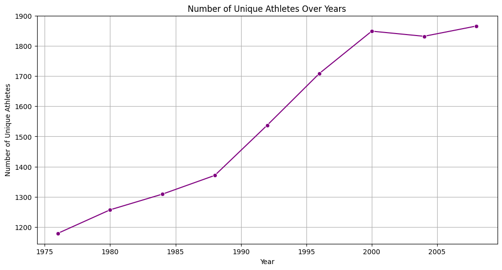

```python
unique_athletes_per_year = df.groupby('Year')['Athlete'].nunique()

plt.figure(figsize=(12, 6))
sns.lineplot(x=unique_athletes_per_year.index, y=unique_athletes_per_year.values, marker='o', color='purple')
plt.title('Number of Unique Athletes Over Years')
plt.xlabel('Year')
plt.ylabel('Number of Unique Athletes')
plt.grid(True)
```

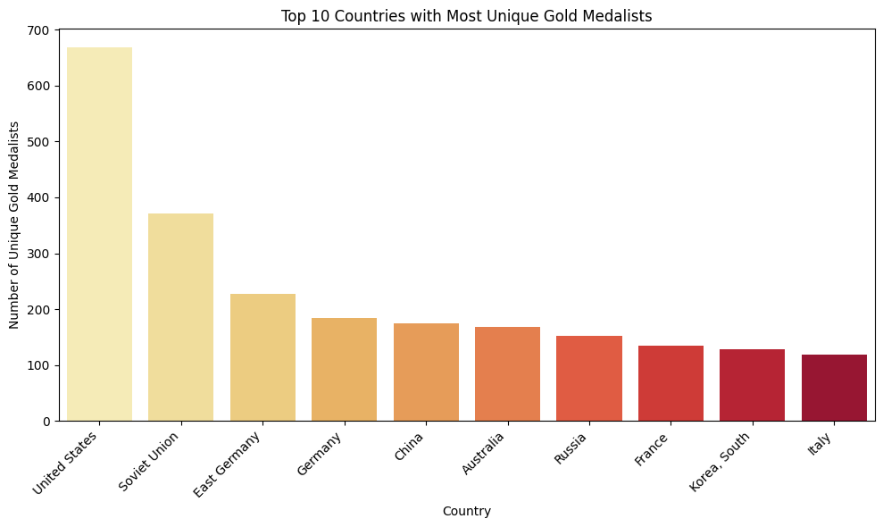

```python
unique_gold_medalists_country = gold_medals_df.groupby('Country')['Athlete'].nunique().sort_values(ascending=False).head(10)

plt.figure(figsize=(10, 6))
sns.barplot(x=unique_gold_medalists_country.index, y=unique_gold_medalists_country.values, palette='YlOrRd')
plt.title('Top 10 Countries with Most Unique Gold Medalists')
plt.xlabel('Country')
plt.ylabel('Number of Unique Gold Medalists')
plt.xticks(rotation=45, ha='right')
plt.tight_layout()
```

[figure not shown]